# Seaborn

Seaborn is a Python data visualization library based on Matplotlib. It provides a high-level interface for drawing attractive and informative statistical graphics. Here are some of the key features and functionalities of Seaborn:

1. **Built-in themes**: Seaborn comes with several built-in themes that make it easy to switch between different visual styles.
2. **Complex visualizations**: Seaborn simplifies the creation of complex visualizations like heatmaps, time series plots, and violin plots.
3. **Statistical aggregation**: Seaborn can handle statistical aggregation to summarize data, making it easier to display data distributions and trends.
4. **Integration with Pandas**: Seaborn works well with Pandas data structures, making it easy to visualize data stored in DataFrames.
5. **Color palettes**: Seaborn provides a variety of color palettes for styling plots, which can be customized to suit the specific requirements of your visualizations.

### Basic Example

Here’s a simple example of how to use Seaborn to create a basic plot:

```
import seaborn as sns
import matplotlib.pyplot as plt

# Load an example dataset
data = sns.load_dataset("tips")

# Create a simple scatter plot
sns.scatterplot(x="total_bill", y="tip", data=data)

# Show the plot
plt.show()
```

### Advanced Example

Creating a more complex plot with Seaborn, such as a heatmap:

```
import seaborn as sns
import matplotlib.pyplot as plt

# Load an example dataset
data = sns.load_dataset("flights")

# Pivot the data to create a matrix format
data_pivot = data.pivot("month", "year", "passengers")

# Create a heatmap
sns.heatmap(data_pivot, annot=True, fmt="d", cmap="YlGnBu")

# Show the plot
plt.show()
```

These examples demonstrate Seaborn’s ability to handle different types of data and create visually appealing plots with minimal code.

```python
import seaborn as sns
import matplotlib.pyplot as plt
import numpy as np
```

## importing data

```python
data=sns.load_dataset("fmri") #loading dataset from seaborn github repository of datasets
data
```

|  | subject | timepoint | event | region | signal |
| --- | --- | --- | --- | --- | --- |
| 0 | s13 | 18 | stim | parietal | -0.017552 |
| 1 | s5 | 14 | stim | parietal | -0.080883 |
| 2 | s12 | 18 | stim | parietal | -0.081033 |
| 3 | s11 | 18 | stim | parietal | -0.046134 |
| 4 | s10 | 18 | stim | parietal | -0.037970 |
| ... | ... | ... | ... | ... | ... |
| 1059 | s0 | 8 | cue | frontal | 0.018165 |
| 1060 | s13 | 7 | cue | frontal | -0.029130 |
| 1061 | s12 | 7 | cue | frontal | -0.004939 |
| 1062 | s11 | 7 | cue | frontal | -0.025367 |
| 1063 | s0 | 0 | cue | parietal | -0.006899 |

1064 rows × 5 columns

# Line Plot

Description: Used to show trends over time or ordered data.

Parameters: x, y: Variables that specify positions on the x and y axes.

hue: Variable in data to map plot aspects to different colors.

size: Variable in data to map plot aspects to different sizes.

style: Variable in data to map plot aspects to different markers.

palette: Colors to use for the different levels of the hue variable.

data: Dataset for the plot.

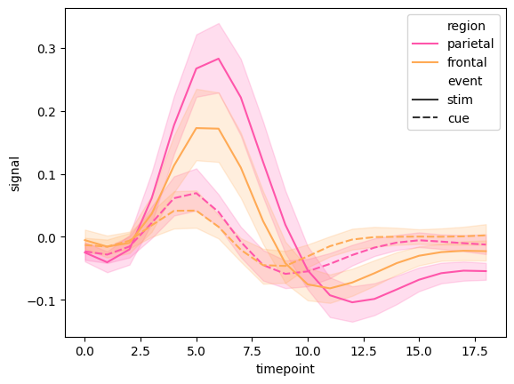

```python
sns.lineplot(data=data, x="timepoint", y="signal",style="event",hue="region",palette="spring")
plt.show()
```

## Bar Plot (sns.barplot)

Description: Used to show the distribution of categorical data with rectangular bars.

Parameters:

x, y: Variables that specify positions on the x and y axes.

hue: Variable in data to map plot aspects to different colors.

data: Dataset for the plot.

estimator: Statistical function to estimate within each categorical bin.

```python
data=sns.load_dataset("titanic")
data
```

|  | survived | pclass | sex | age | sibsp | parch | fare | embarked | class | who | adult_male | deck | embark_town | alive | alone |
| --- | --- | --- | --- | --- | --- | --- | --- | --- | --- | --- | --- | --- | --- | --- | --- |
| 0 | 0 | 3 | male | 22.0 | 1 | 0 | 7.2500 | S | Third | man | True | NaN | Southampton | no | False |
| 1 | 1 | 1 | female | 38.0 | 1 | 0 | 71.2833 | C | First | woman | False | C | Cherbourg | yes | False |
| 2 | 1 | 3 | female | 26.0 | 0 | 0 | 7.9250 | S | Third | woman | False | NaN | Southampton | yes | True |
| 3 | 1 | 1 | female | 35.0 | 1 | 0 | 53.1000 | S | First | woman | False | C | Southampton | yes | False |
| 4 | 0 | 3 | male | 35.0 | 0 | 0 | 8.0500 | S | Third | man | True | NaN | Southampton | no | True |
| ... | ... | ... | ... | ... | ... | ... | ... | ... | ... | ... | ... | ... | ... | ... | ... |
| 886 | 0 | 2 | male | 27.0 | 0 | 0 | 13.0000 | S | Second | man | True | NaN | Southampton | no | True |
| 887 | 1 | 1 | female | 19.0 | 0 | 0 | 30.0000 | S | First | woman | False | B | Southampton | yes | True |
| 888 | 0 | 3 | female | NaN | 1 | 2 | 23.4500 | S | Third | woman | False | NaN | Southampton | no | False |
| 889 | 1 | 1 | male | 26.0 | 0 | 0 | 30.0000 | C | First | man | True | C | Cherbourg | yes | True |
| 890 | 0 | 3 | male | 32.0 | 0 | 0 | 7.7500 | Q | Third | man | True | NaN | Queenstown | no | True |

891 rows × 15 columns

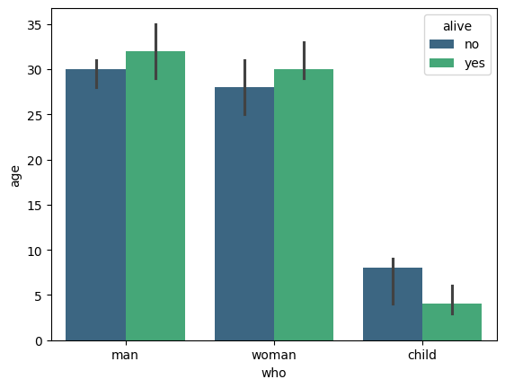

```python
sns.barplot(data=data,y="age",x="who",hue="alive",estimator='median',palette="viridis")
plt.show()
```

## Histogram (sns.histplot)

Description: A histogram is used to visualize the distribution of a single continuous variable by dividing the data into bins and counting the number of observations in each bin.

Parameters:

data: Dataset for the plot.

x: Variable to plot on the x-axis.

hue: Variable in data to map plot aspects to different colors.

bins: Number of bins or binning strategy.

binwidth: Width of each bin.

binrange: Lower and upper range of bins.

stat: Aggregate statistic to compute in each bin (e.g., "count", "density").

common_bins: Use the same bins for all subsets of data.

common_norm: Normalize across all subsets.

multiple: Display multiple distributions ("layer", "dodge", "stack", "fill").

element: Plot element type ("bars", "step", "poly").

fill: Whether to fill the plot.

kde: Whether to plot a kernel density estimate.

```python
data=sns.load_dataset("tips")
data
```

|  | total_bill | tip | sex | smoker | day | time | size |
| --- | --- | --- | --- | --- | --- | --- | --- |
| 0 | 16.99 | 1.01 | Female | No | Sun | Dinner | 2 |
| 1 | 10.34 | 1.66 | Male | No | Sun | Dinner | 3 |
| 2 | 21.01 | 3.50 | Male | No | Sun | Dinner | 3 |
| 3 | 23.68 | 3.31 | Male | No | Sun | Dinner | 2 |
| 4 | 24.59 | 3.61 | Female | No | Sun | Dinner | 4 |
| ... | ... | ... | ... | ... | ... | ... | ... |
| 239 | 29.03 | 5.92 | Male | No | Sat | Dinner | 3 |
| 240 | 27.18 | 2.00 | Female | Yes | Sat | Dinner | 2 |
| 241 | 22.67 | 2.00 | Male | Yes | Sat | Dinner | 2 |
| 242 | 17.82 | 1.75 | Male | No | Sat | Dinner | 2 |
| 243 | 18.78 | 3.00 | Female | No | Thur | Dinner | 2 |

244 rows × 7 columns

```
[]
```

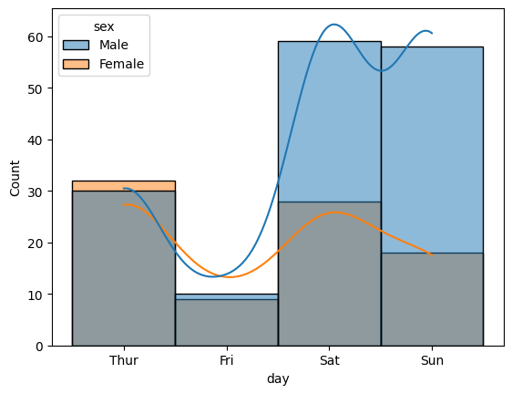

```python
sns.histplot(data=data, x="day",hue="sex",kde=True)
plt.plot()
```

```
[]
```

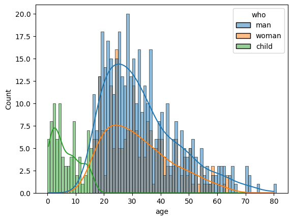

```python
data=sns.load_dataset("titanic")
sns.histplot(data=data, x="age",hue="who",kde=True,discrete=True) #discrete for closely packed data
plt.plot()
```

## Scatter Plot (sns.scatterplot)

Description: Used to show the relationship between two continuous variables. show comparison of two columns based on values

Parameters: x, y: Variables that specify positions on the x and y axes. hue: Variable in data to map plot aspects to different colors. size: Variable in data to map plot aspects to different sizes. style: Variable in data to map plot aspects to different markers. palette: Colors to use for the different levels of the hue variable. data: Dataset for the plot.

```python
data=sns.load_dataset("tips")
data
```

|  | total_bill | tip | sex | smoker | day | time | size |
| --- | --- | --- | --- | --- | --- | --- | --- |
| 0 | 16.99 | 1.01 | Female | No | Sun | Dinner | 2 |
| 1 | 10.34 | 1.66 | Male | No | Sun | Dinner | 3 |
| 2 | 21.01 | 3.50 | Male | No | Sun | Dinner | 3 |
| 3 | 23.68 | 3.31 | Male | No | Sun | Dinner | 2 |
| 4 | 24.59 | 3.61 | Female | No | Sun | Dinner | 4 |
| ... | ... | ... | ... | ... | ... | ... | ... |
| 239 | 29.03 | 5.92 | Male | No | Sat | Dinner | 3 |
| 240 | 27.18 | 2.00 | Female | Yes | Sat | Dinner | 2 |
| 241 | 22.67 | 2.00 | Male | Yes | Sat | Dinner | 2 |
| 242 | 17.82 | 1.75 | Male | No | Sat | Dinner | 2 |
| 243 | 18.78 | 3.00 | Female | No | Thur | Dinner | 2 |

244 rows × 7 columns

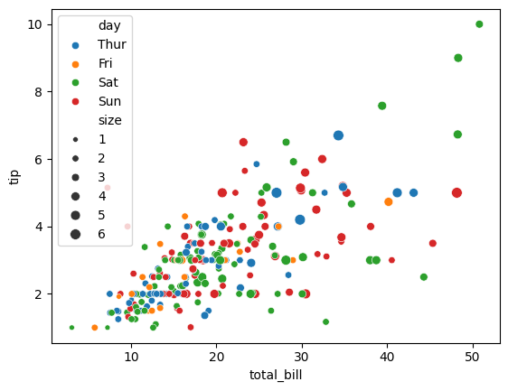

```python
sns.scatterplot(data=data, x='total_bill',y='tip',hue="day",size='size')
plt.show()
```

## Box Plot (sns.boxplot)

Description: Used to show the distribution of data based on a five-number summary ("minimum", first quartile (Q1), median, third quartile (Q3), and "maximum"). Parameters: x, y: Variables that specify positions on the x and y axes. hue: Variable in data to map plot aspects to different colors. data: Dataset for the plot. order: Order to plot the categorical levels

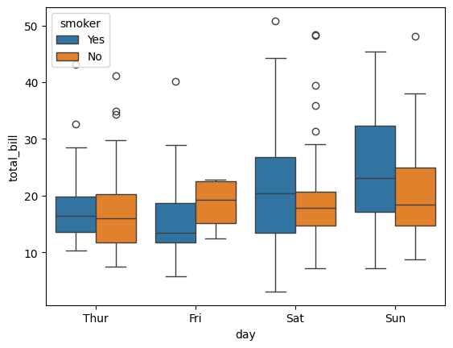

```python
data = sns.load_dataset("tips")
sns.boxplot(x="day", y="total_bill", hue="smoker", data=data)
plt.show()
```

## Violin Plot (sns.violinplot)

Description: Used to show the distribution of the data and its probability density. Parameters: x, y: Variables that specify positions on the x and y axes. hue: Variable in data to map plot aspects to different colors. data: Dataset for the plot. split: Whether to split the violins for easier comparison.

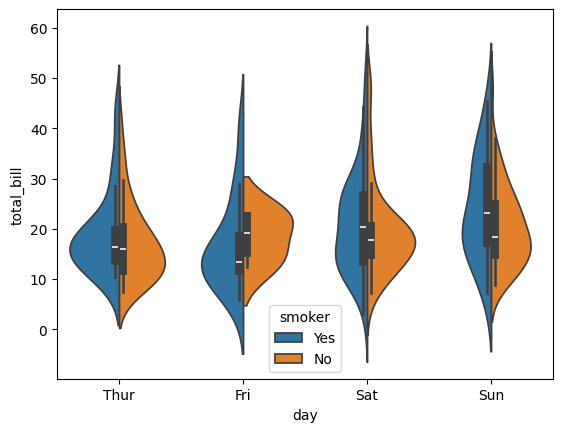

```python
data = sns.load_dataset("tips")
sns.violinplot(x="day", y="total_bill", hue="smoker", data=data, split=True)
plt.show()
```

## Heatmap (sns.heatmap)

Description: Used to display data as a matrix of color-coded cells. Parameters: data: 2D dataset that can be coerced into an ndarray. annot: If True, write the data value in each cell. fmt: String formatting code to use when adding annotations. cmap: Colormap to use for the plot. linewidths: Width of the lines that will divide each cell.

sns.heatmap: A Seaborn function to create a heatmap, which is a graphical representation of data where values are represented with colors. data_pivot: The pivoted DataFrame used to generate the heatmap. annot=True: Annotates each cell with the numeric value. fmt="d": Formats the annotation as an integer. cmap="YlGnBu": Specifies the colormap to use (Yellow-Green-Blue in this case).

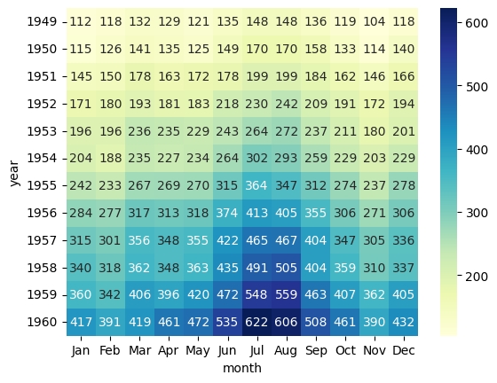

```python
# Load an example dataset
data = sns.load_dataset("flights")

# Pivot the data to create a matrix format
data_pivot = data.pivot(index="year", columns="month", values="passengers")

# Create a heatmap
sns.heatmap(data_pivot, annot=True, fmt="d", cmap="YlGnBu")

# Show the plot
plt.show()
```

## Count Plot (sns.countplot)

Description: Used to show the counts of observations in each categorical bin using bars. Parameters: x, y: Variables that specify positions on the x and y axes. hue: Variable in data to map plot aspects to different colors. data: Dataset for the plot.

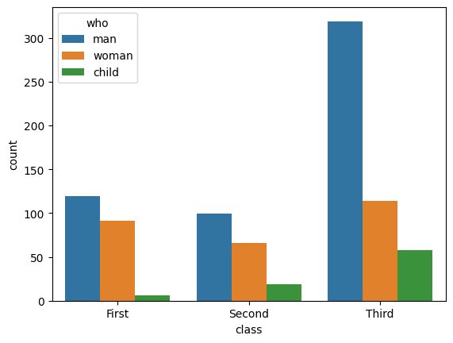

```python
data = sns.load_dataset("titanic")
sns.countplot(x="class", hue="who", data=data)
plt.show()
```

## Pair Plot (sns.pairplot)

Description: Used to plot pairwise relationships in a dataset. Parameters: data: Dataset for the plot. hue: Variable in data to map plot aspects to different colors. palette: Colors to use for the different levels of the hue variable. markers: Markers for the scatter plot.

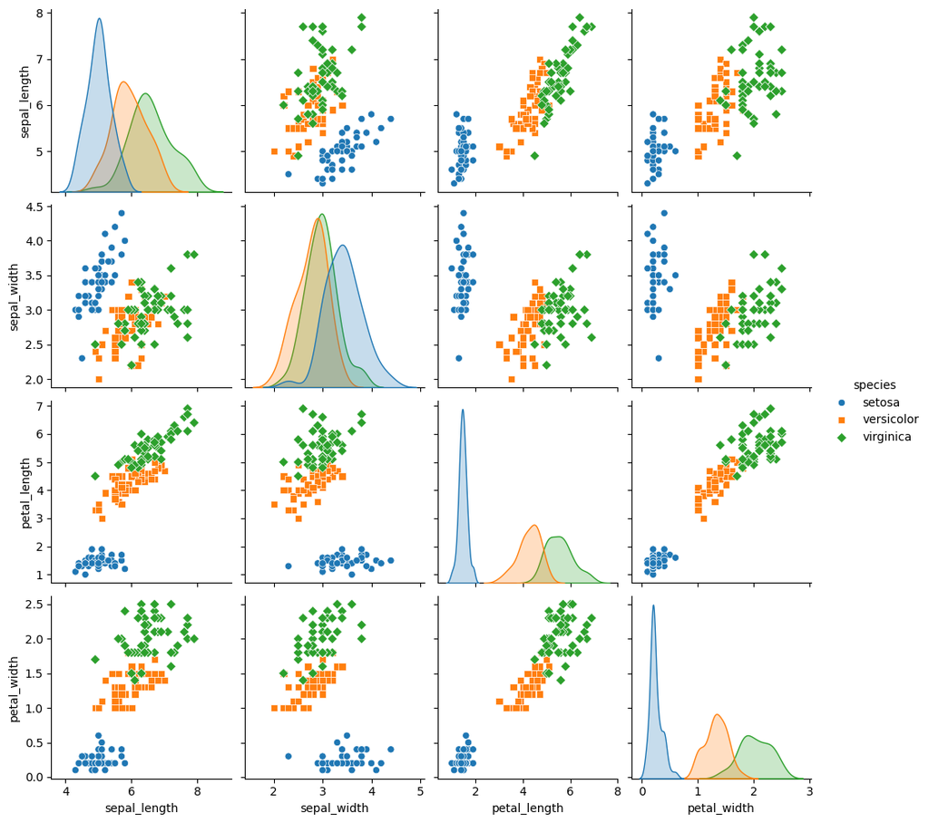

```python
data = sns.load_dataset("iris")
sns.pairplot(data, hue="species", markers=["o", "s", "D"])
plt.show()
```

## Facet Grid (sns.FacetGrid)

Description: Used to plot multiple instances of the same plot type, each for different subsets of the dataset. Parameters: data: Dataset for the plot. row, col: Variables that define subsets of the data, mapped to rows and columns of the grid. hue: Variable in data to map plot aspects to different colors.

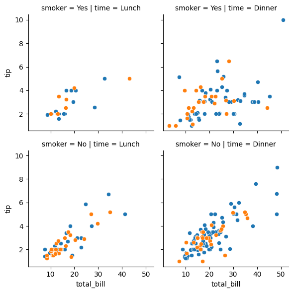

```python
data = sns.load_dataset("tips")
g = sns.FacetGrid(data, col="time", row="smoker", hue="sex")
g.map(sns.scatterplot, "total_bill", "tip")
plt.show()
```

## Joint Plot (sns.jointplot)

Description: Used to draw a plot of two variables with bivariate and univariate graphs. Parameters: x, y: Variables that specify positions on the x and y axes. data: Dataset for the plot. kind: Type of plot to draw ("scatter", "kde", "hist", etc.).

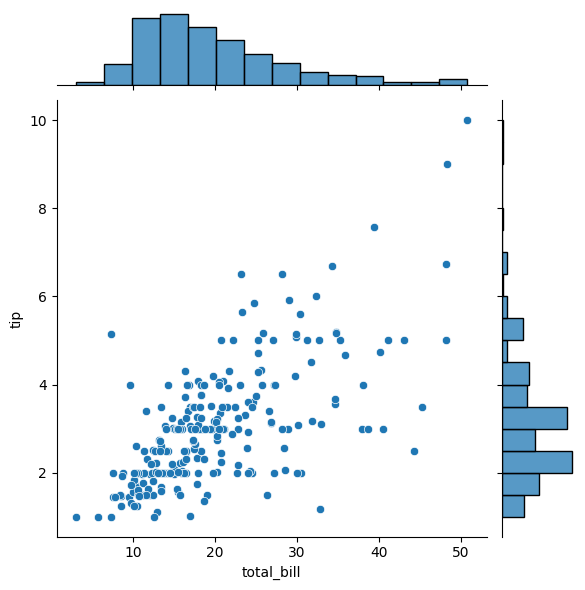

```python
data = sns.load_dataset("tips")
sns.jointplot(x="total_bill", y="tip", data=data, kind="scatter")
plt.show()
```

### Strip Plot (`sns.stripplot`)

**Description**: A strip plot is used to display the distribution of a single categorical variable. It draws a scatterplot where one of the variables is categorical, which helps visualize the distribution of data points within each category.

**Parameters**:

- **`data`**: Dataset for the plot.
- **`x`**: Variable to plot on the x-axis (usually categorical).
- **`y`**: Variable to plot on the y-axis (usually continuous).
- **`hue`**: Variable in data to map plot aspects to different colors.
- **`jitter`**: Amount of jitter (only along the categorical axis) to apply.
- **`dodge`**: When using `hue`, whether to separate the strips for different levels of the hue variable.
- **`palette`**: Colors to use for the different levels of the hue variable.
- **`size`**: Size of the points.
- **`orient`**: Orientation of the plot (either 'v' for vertical or 'h' for horizontal).

### Example Usage

1. **Basic Strip Plot**:

   ```
   import seaborn as sns
   import matplotlib.pyplot as plt

   # Load an example dataset
   data = sns.load_dataset("tips")

   # Create a strip plot
   sns.stripplot(x="day", y="total_bill", data=data)

   # Show the plot
   plt.show()
   ```

2. **Strip Plot with Jitter**:

   ```
   sns.stripplot(x="day", y="total_bill", data=data, jitter=True)
   plt.show()
   ```

3. **Strip Plot with Hue**:

   ```
   sns.stripplot(x="day", y="total_bill", hue="sex", data=data, palette="Set2")
   plt.show()
   ```

4. **Strip Plot with Dodge**:

   ```
   sns.stripplot(x="day", y="total_bill", hue="sex", data=data, dodge=True)
   plt.show()
   ```

5. **Horizontal Strip Plot**:

   ```
   sns.stripplot(y="day", x="total_bill", data=data, jitter=True)
   plt.show()
   ```

### Explanation of Parameters

- **`data`**: The dataset to plot.
- **`x`**: The column name of the data you want to plot on the x-axis (usually a categorical variable).
- **`y`**: The column name of the data you want to plot on the y-axis (usually a continuous variable).
- **`hue`**: Splits the data by the specified variable and color-codes them.
- **`jitter`**: Adds random noise to the data points to prevent overlapping. Useful for visualizing the distribution of data points within each category.
- **`dodge`**: When using the `hue` parameter, this separates the strips for different levels of the hue variable.
- **`palette`**: Specifies the colors to use for the different levels of the hue variable.
- **`size`**: Specifies the size of the points.
- **`orient`**: Specifies the orientation of the plot (vertical or horizontal).

### Use Cases

- **Visualizing Categorical Data**: Strip plots are great for showing the distribution of data points within different categories.
- **Comparing Distributions**: By using the `hue` parameter, you can compare the distributions of different subsets of the data within the same categories.
- **Adding Jitter**: Adding jitter helps in visualizing dense data points by spreading them out, making the distribution clearer.

### Example Scenarios

1. **Comparing Tips Given on Different Days**:

   ```
   sns.stripplot(x="day", y="tip", data=data)
   plt.show()
   ```

2. **Comparing Total Bills by Day and Sex**:

   ```
   sns.stripplot(x="day", y="total_bill", hue="sex", data=data, dodge=True)
   plt.show()
   ```

3. **Visualizing the Distribution of Total Bills**:

   ```
   sns.stripplot(x="total_bill", data=data)
   plt.show()
   ```

By using the strip plot, you can effectively visualize the distribution and spread of data points within categorical variables, and gain insights into patterns and trends within your dataset.

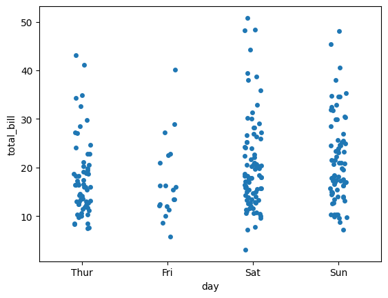

```python
import seaborn as sns
import matplotlib.pyplot as plt

# Load an example dataset
data = sns.load_dataset("tips")

# Create a strip plot
sns.stripplot(x="day", y="total_bill", data=data)

# Show the plot
plt.show()
```

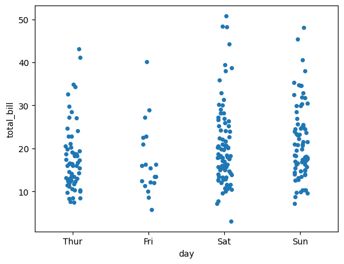

```python
sns.stripplot(x="day", y="total_bill", data=data, jitter=True)
plt.show()
```

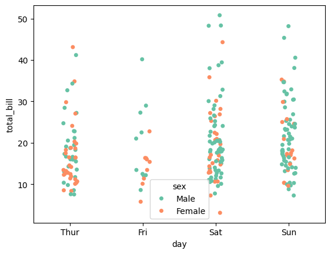

```python
sns.stripplot(x="day", y="total_bill", hue="sex", data=data, palette="Set2")
plt.show()
```

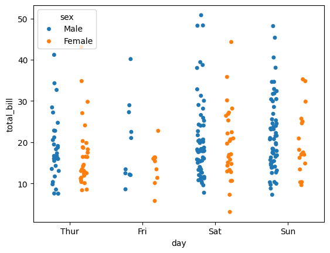

```python
sns.stripplot(x="day", y="total_bill", hue="sex", data=data, dodge=True)
plt.show()
```

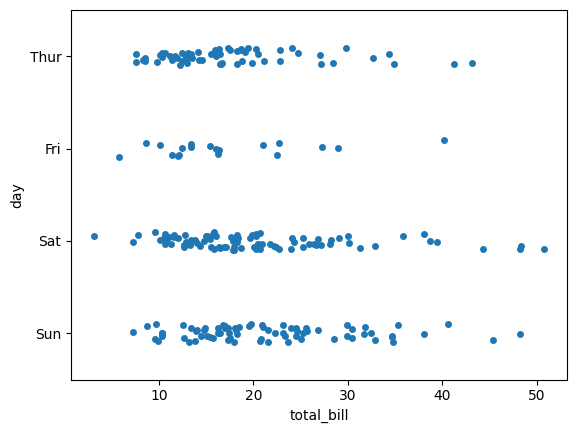

```python
sns.stripplot(y="day", x="total_bill", data=data, jitter=True)
plt.show()
```

### Categorical Plot (`sns.catplot`)

**Description**: `sns.catplot` is a versatile function in Seaborn for creating various types of categorical plots. It combines the functionality of several other categorical plots, such as strip plots, box plots, and bar plots, into one unified interface. This makes it easier to create complex visualizations with consistent styling.

**Parameters**:

- **`data`**: Dataset for the plot.
- **`x`**: Variable to plot on the x-axis (categorical).
- **`y`**: Variable to plot on the y-axis (usually continuous).
- **`hue`**: Variable in data to map plot aspects to different colors.
- **`kind`**: Type of plot to draw (e.g., "strip", "swarm", "box", "violin", "boxen", "point", "bar", "count").
- **`col`**: Variable to create subplot columns.
- **`row`**: Variable to create subplot rows.
- **`palette`**: Colors to use for the different levels of the hue variable.
- **`height`**: Height of each subplot.
- **`aspect`**: Aspect ratio of each subplot.
- **`order`**: Order to plot the categorical levels on the x-axis.
- **`col_order`**: Order to plot the categorical levels on the columns.
- **`row_order`**: Order to plot the categorical levels on the rows.

### Example Usage

1. **Basic Cat Plot (Strip Plot)**:

   ```
   import seaborn as sns
   import matplotlib.pyplot as plt

   # Load an example dataset
   data = sns.load_dataset("tips")

   # Create a categorical plot with kind="strip"
   sns.catplot(x="day", y="total_bill", kind="strip", data=data)

   # Show the plot
   plt.show()
   ```

2. **Swarm Plot**:

   ```
   sns.catplot(x="day", y="total_bill", kind="swarm", data=data)
   plt.show()
   ```

3. **Box Plot**:

   ```
   sns.catplot(x="day", y="total_bill", kind="box", data=data)
   plt.show()
   ```

4. **Violin Plot**:

   ```
   sns.catplot(x="day", y="total_bill", kind="violin", data=data)
   plt.show()
   ```

5. **Boxen Plot**:

   ```
   sns.catplot(x="day", y="total_bill", kind="boxen", data=data)
   plt.show()
   ```

6. **Point Plot**:

   ```
   sns.catplot(x="day", y="total_bill", kind="point", data=data)
   plt.show()
   ```

7. **Bar Plot**:

   ```
   sns.catplot(x="day", y="total_bill", kind="bar", data=data)
   plt.show()
   ```

8. **Count Plot**:

   ```
   sns.catplot(x="day", kind="count", data=data)
   plt.show()
   ```

9. **Facet Grid (Multiple Subplots)**:

   ```
   sns.catplot(x="day", y="total_bill", hue="sex", col="time", kind="swarm", data=data)
   plt.show()
   ```

### Explanation of Parameters

- **`data`**: The dataset to plot.
- **`x`**: The column name of the data you want to plot on the x-axis (usually a categorical variable).
- **`y`**: The column name of the data you want to plot on the y-axis (usually a continuous variable).
- **`hue`**: Splits the data by the specified variable and color-codes them.
- **`kind`**: Specifies the type of plot to draw. Options include "strip", "swarm", "box", "violin", "boxen", "point", "bar", and "count".
- **`col`**: Creates subplot columns based on the specified variable.
- **`row`**: Creates subplot rows based on the specified variable.
- **`palette`**: Specifies the colors to use for the different levels of the hue variable.
- **`height`**: Specifies the height of each subplot.
- **`aspect`**: Specifies the aspect ratio of each subplot.
- **`order`**: Specifies the order to plot the categorical levels on the x-axis.
- **`col_order`**: Specifies the order to plot the categorical levels on the columns.
- **`row_order`**: Specifies the order to plot the categorical levels on the rows.

### Use Cases

1. **Visualizing Categorical Data**: Cat plots are great for showing the distribution of data points within different categories.
2. **Comparing Distributions**: By using the `hue`, `col`, and `row` parameters, you can compare the distributions of different subsets of the data within the same categories.
3. **Customizable Plots**: Cat plots offer a variety of plot types and customization options, making it easy to tailor visualizations to specific needs.

### Example Scenarios

1. **Comparing Tips Given on Different Days with Different Plot Types**:

   ```
   sns.catplot(x="day", y="tip", kind="violin", data=data)
   plt.show()
   ```

2. **Comparing Total Bills by Day and Sex with Facet Grid**:

   ```
   sns.catplot(x="day", y="total_bill", hue="sex", col="time", kind="box", data=data)
   plt.show()
   ```

3. **Visualizing the Distribution of Total Bills with Different Plot Types**:

   ```
   sns.catplot(x="total_bill", kind="count", data=data)
   plt.show()
   ```

By using the cat plot, you can create a wide range of categorical plots with a consistent interface and easily compare distributions across different subsets of your data.

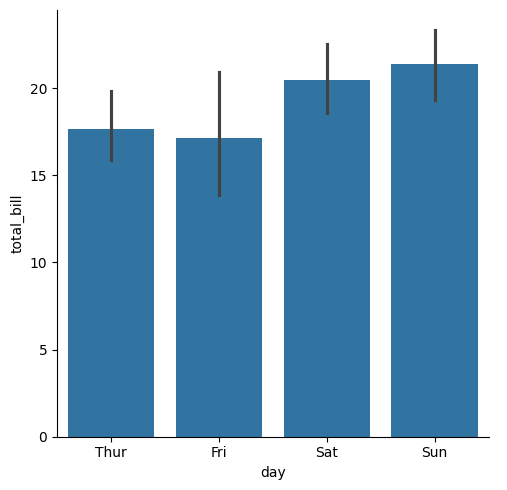

```python
import seaborn as sns
import matplotlib.pyplot as plt

# Load an example dataset
data = sns.load_dataset("tips")

# Create a categorical plot with kind="strip"
sns.catplot(x="day", y="total_bill", kind="bar", data=data) #change kind to bar,his,lineplot,voilin etc to get the required plot

# Show the plot
plt.show()
```

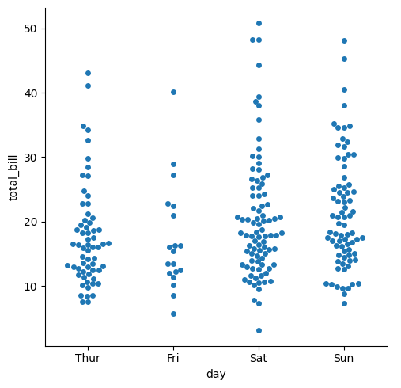

```python
sns.catplot(x="day", y="total_bill", kind="swarm", data=data)
plt.show()
```

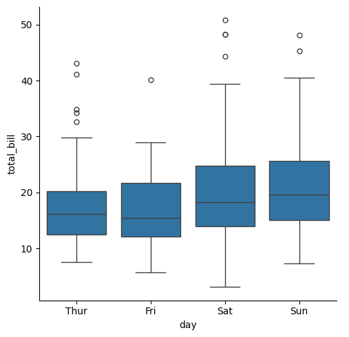

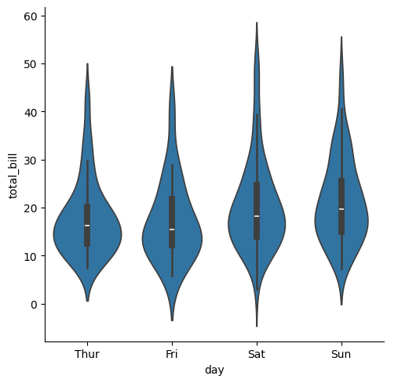

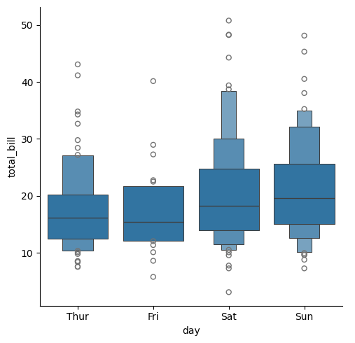

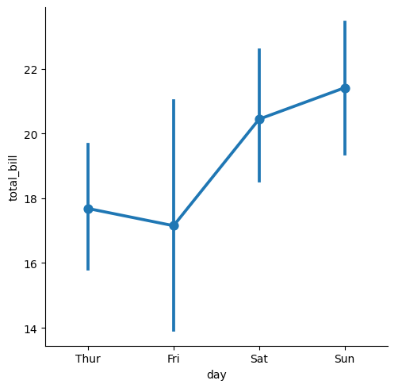

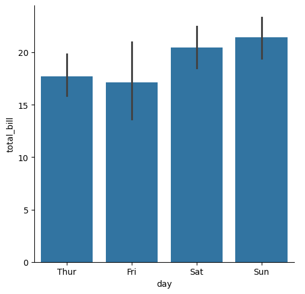

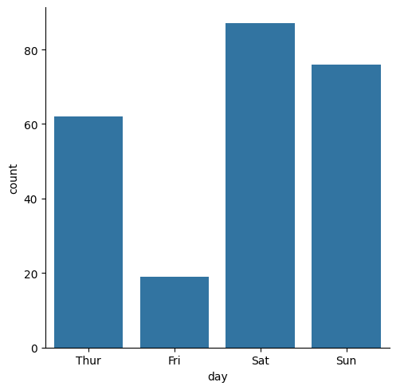

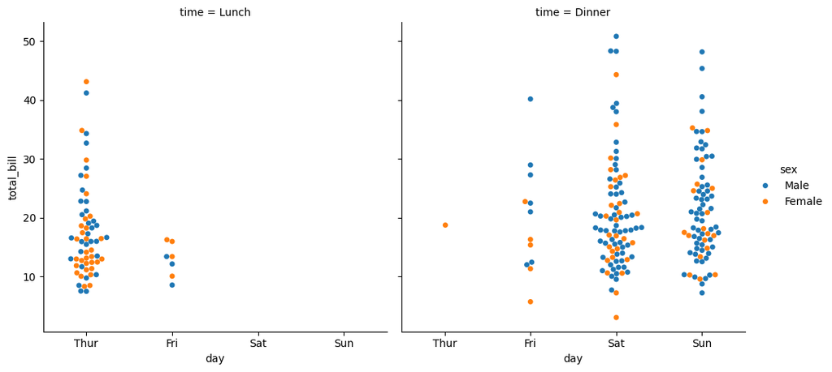

```python
#Box Plot:

sns.catplot(x="day", y="total_bill", kind="box", data=data)
plt.show()
#Violin Plot:

sns.catplot(x="day", y="total_bill", kind="violin", data=data)
plt.show()
#Boxen Plot:

sns.catplot(x="day", y="total_bill", kind="boxen", data=data)
plt.show()
#Point Plot:

sns.catplot(x="day", y="total_bill", kind="point", data=data)
plt.show()
#Bar Plot:

sns.catplot(x="day", y="total_bill", kind="bar", data=data)
plt.show()
#Count Plot:

sns.catplot(x="day", kind="count", data=data)
plt.show()
#Facet Grid (Multiple Subplots):

sns.catplot(x="day", y="total_bill", hue="sex", col="time", kind="swarm", data=data)
plt.show()
```

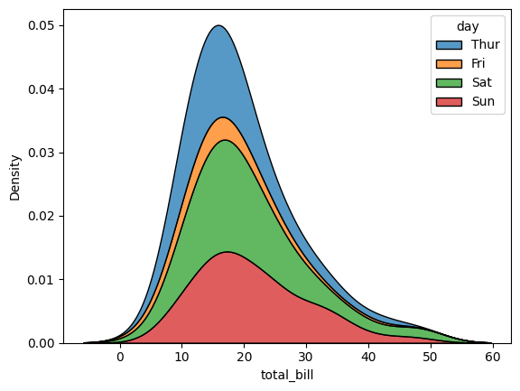

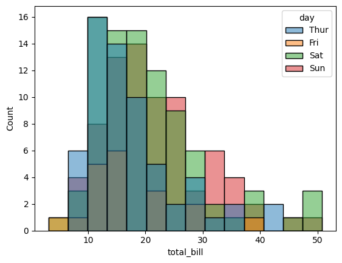

```python
sns.kdeplot( x="total_bill", hue="day", data=data,multiple="stack")
plt.show()
sns.histplot( x="total_bill", hue="day", data=data)
plt.show()
```